# Text Analysis Using Twitter

## Cleaning and Exploring Twitter Data using REGEX

**By**: *Victor Cornejo*

## Key Points

In this project I practiced:

- Conducting Data Cleaning and EDA on a text-based dataset.
- Manipulating data in pandas with the datetime and string accessors.
- Writing regular expressions and using pandas regex methods.
- Performing sentiment analysis on social media using VADER.

```python
# Run this cell to set up your notebook
import numpy as np
import pandas as pd
import matplotlib.pyplot as plt
import seaborn as sns
import re

from ds100_utils import *

# Ensure that Pandas shows at least 280 characters in columns, so we can see full tweets
pd.set_option('max_colwidth', 280)
plt.style.use('fivethirtyeight')
sns.set()
sns.set_context("talk")

def horiz_concat_df(dict_of_df, head=None):
    """
    Horizontally concatenante multiple DataFrames for easier visualization.
    Each DataFrame must have the same columns.
    """
    df = pd.concat([df.reset_index(drop=True) for df in dict_of_df.values()], axis=1, keys=dict_of_df.keys())
    if head is None:
        return df
    return df.head(head)
```

## Importing the Data

The data for this assignment was obtained using the [Twitter APIs](https://developer.twitter.com/en/docs/twitter-api).

```python
# importing from local directory
from os import listdir
for f in listdir("data"):
    print(f)
```

```
elonmusk_recent_tweets.txt
Cristiano_recent_tweets.txt
EmmanuelMacron_recent_tweets.txt
BernieSanders_recent_tweets.txt
.ipynb_checkpoints
AOC_recent_tweets.txt
BillGates_recent_tweets.txt
```

### Read

Pandas has built-in readers for many different file formats including the file format used here to store tweets.

1. I used the read function to populate the `tweets` dictionary with the tweets for: `AOC`, `Cristiano`, and `elonmusk`. The keys of `tweets` are the handles of the users, and the values should are the corresponding DataFrames.
2. I set the index of each DataFrame to correspond to the `id` of each tweet.

```python
tweets = {
    "AOC": pd.read_json("data/AOC_recent_tweets.txt").set_index("id"),
    "Cristiano": pd.read_json("data/Cristiano_recent_tweets.txt").set_index("id"),
    "elonmusk": pd.read_json("data/elonmusk_recent_tweets.txt").set_index("id"),
}
```

For fun, the following cells will show the first 5 tweets for Elon Musk (and a lot of information about those tweets).

```python
tweets["elonmusk"].head()
```

| id | created_at | id_str | full_text | truncated | display_text_range | entities | extended_entities | source | in_reply_to_status_id | in_reply_to_status_id_str | ... | favorite_count | favorited | retweeted | possibly_sensitive | lang | retweeted_status | quoted_status_id | quoted_status_id_str | quoted_status_permalink | quoted_status |
| --- | --- | --- | --- | --- | --- | --- | --- | --- | --- | --- | --- | --- | --- | --- | --- | --- | --- | --- | --- | --- | --- |
| 1357991946082418690 | 2021-02-06 09:58:04+00:00 | 1357991946082418688 | The Second Last Kingdom https://t.co/Je4EI88HmV | False | [0, 23] | {'hashtags': [], 'symbols': [], 'user_mentions': [], 'urls': [], 'media': [{'id': 1357991942471094275, 'id_str': '1357991942471094275', 'indices': [24, 47], 'media_url': 'http://pbs.twimg.com/media/Et… | {'media': [{'id': 1357991942471094275, 'id_str': '1357991942471094275', 'indices': [24, 47], 'media_url': 'http://pbs.twimg.com/media/EtiOegrVEAMCgZE.jpg', 'media_url_https': 'https://pbs.twimg.com/me… | <a href="http://twitter.com/download/iphone" rel="nofollow">Twitter for iPhone</a> | NaN | NaN | ... | 352096 | False | False | 0.0 | en | NaN | NaN | NaN | NaN | NaN |
| 1357973565413367808 | 2021-02-06 08:45:02+00:00 | 1357973565413367808 | @DumDin7 @Grimezsz Haven’t heard that name in years … | False | [19, 53] | {'hashtags': [], 'symbols': [], 'user_mentions': [{'screen_name': 'DumDin7', 'name': 'Dum Din', 'id': 1279896279733145601, 'id_str': '1279896279733145601', 'indices': [0, 8]}, {'screen_name': 'Grimezs… | NaN | <a href="http://twitter.com/download/iphone" rel="nofollow">Twitter for iPhone</a> | 1.357973e+18 | 1.357973e+18 | ... | 2155 | False | False | NaN | en | NaN | NaN | NaN | NaN | NaN |
| 1357972904663687173 | 2021-02-06 08:42:25+00:00 | 1357972904663687168 | @Grimezsz Dogecake | False | [10, 18] | {'hashtags': [], 'symbols': [], 'user_mentions': [{'screen_name': 'Grimezsz', 'name': '𝑪𝒍𝒂𝒊𝒓𝒆 𝒅𝒆 𝑳𝒖𝒏𝒆࿎', 'id': 276540738, 'id_str': '276540738', 'indices': [0, 9]}], 'urls': []} | NaN | <a href="http://twitter.com/download/iphone" rel="nofollow">Twitter for iPhone</a> | 1.357835e+18 | 1.357835e+18 | ... | 5373 | False | False | NaN | en | NaN | NaN | NaN | NaN | NaN |
| 1357970517165182979 | 2021-02-06 08:32:55+00:00 | 1357970517165182976 | YOLT\n\nhttps://t.co/cnOf9yjpF1 | False | [0, 29] | {'hashtags': [], 'symbols': [], 'user_mentions': [], 'urls': [{'url': 'https://t.co/cnOf9yjpF1', 'expanded_url': 'https://m.youtube.com/watch?v=05QJlF06F4s', 'display_url': 'm.youtube.com/watch?v=05QJ… | NaN | <a href="http://twitter.com/download/iphone" rel="nofollow">Twitter for iPhone</a> | NaN | NaN | ... | 62717 | False | False | 0.0 | en | NaN | NaN | NaN | NaN | NaN |
| 1357964347813687296 | 2021-02-06 08:08:24+00:00 | 1357964347813687296 | @Kristennetten That’s Damian | False | [15, 28] | {'hashtags': [], 'symbols': [], 'user_mentions': [{'screen_name': 'Kristennetten', 'name': 'K10✨', 'id': 985686123123949568, 'id_str': '985686123123949568', 'indices': [0, 14]}], 'urls': []} | NaN | <a href="http://twitter.com/download/iphone" rel="nofollow">Twitter for iPhone</a> | 1.357964e+18 | 1.357964e+18 | ... | 5726 | False | False | NaN | en | NaN | NaN | NaN | NaN | NaN |

5 rows × 30 columns

### Why Read?

There are many ways we could choose to read tweets. Why might someone be interested in doing data analysis on tweets? What kind of person or institution might be interested in this kind of analysis. Why a data analysis of tweets might be interesting or useful for them.

Well, we could imagine a data analyst: Palantir; Cambridge Analytica; Someone in Marketing, in the spectacle world to predict trends, someone in the stock market to predict where bitcoin will be next day based on what Elon says, a political analyst to predict the outcome of the next election, etc.

## Source Analysis

In some cases, the Twitter feed of a public figure may be partially managed by a public relations firm. In these cases, the device used to post the tweet may help reveal whether it was the individual (e.g., from an iPhone) or a public relations firm (e.g., TweetDeck). The tweets collected in our data contain the source information but it is formatted strangely :(

```python
# just run this cell
tweets["Cristiano"][["source"]]
```

| id | source |
| --- | --- |
| 1358137564587319299 | <a href="http://twitter.com/download/iphone" rel="nofollow">Twitter for iPhone</a> |
| 1357379984399212545 | <a href="http://twitter.com/download/iphone" rel="nofollow">Twitter for iPhone</a> |
| 1356733030962987008 | <a href="http://twitter.com/download/iphone" rel="nofollow">Twitter for iPhone</a> |
| 1355924395064233986 | <a href="http://twitter.com/download/iphone" rel="nofollow">Twitter for iPhone</a> |
| 1355599316300292097 | <a href="http://twitter.com/download/iphone" rel="nofollow">Twitter for iPhone</a> |
| ... | ... |
| 32514882561638401 | <a href="http://www.whosay.com" rel="nofollow">WhoSay</a> |
| 32513604662071296 | <a href="http://www.whosay.com" rel="nofollow">WhoSay</a> |
| 32511823722840064 | <a href="http://www.whosay.com" rel="nofollow">WhoSay</a> |
| 32510294081146881 | <a href="http://www.whosay.com" rel="nofollow">WhoSay</a> |
| 32508748819857410 | <a href="http://www.whosay.com" rel="nofollow">WhoSay</a> |

3198 rows × 1 columns

After spotting a pattern, I used a regular expression to convert this messy HTML snippet into something more readable. Something Like: `<a href="http://twitter.com/download/iphone" rel="nofollow">Twitter for iPhone</a>` as `Twitter for iPhone`.

### Patterns

I used the Python `re` library to cleanup the above test string. Below, I wrote a regular expression that would match the **HTML tag** and assign it to the variable `a_pattern`. We then use the `re.sub` function to substitute anything that matches the pattern with an empty string `""`.

An HTML tag is defined as a `<` character followed by zero or more non-`>` characters, followed by a `>` character. That is, `<a>` and `</a>` are both considered *separate* HTML tags.

```python
a_pattern = r"<[^>]*>"
test_str = '<a href="http://twitter.com/download/iphone" rel="nofollow">Twitter for iPhone</a>'
re.sub(a_pattern, "", test_str)
```

```
'Twitter for iPhone'
```

### Capture

Rather than writing a regular expression to detect and remove the HTML tags I could instead write a regular expression to **capture** the device name between the angle brackets. Here I used [**capturing groups**](https://docs.python.org/3/howto/regex.html#grouping) by placing parenthesis around the part of the regular expression I wanted to return. For example, to capture the `21` in the string `08/21/83` we could use the pattern `r"08/(..)/83"`.

```python
b_pattern = r">([^>]*)<"
test_str = '<a href="http://twitter.com/download/iphone" rel="nofollow">Twitter for iPhone</a>'
re.findall(b_pattern, test_str)
```

```
['Twitter for iPhone']
```

### Extract

Using [`Series.str.extract`](https://pandas.pydata.org/docs/reference/api/pandas.Series.str.extract.html), added a new column called `"device"` to **all** of the DataFrames in `tweets` containing just the text describing the device (without the HTML tags).

```python
def add_device(df):
    df["device"] = df["source"].str.extract(b_pattern)
    return df
```

```python
tweets = {k: add_device(v) for k, v in tweets.items()}
```

### Frequency

To examine the most frequently used devices by each individual, I implemented the `most_freq` function that takes in a `Series` and returns a new `Series` containing the `k` most commonly occurring entries in the first series, where the values are the counts of the entries and the indices are the entries themselves.

For example:

```
most_freq(pd.Series(["A", "B", "A", "C", "B", "A"]), k=2)
```

returns:

```
A    3
B    2
dtype: int64
```

```python
def most_freq(series, k = 5):
    return series.value_counts().nlargest(k)

most_freq(tweets["Cristiano"]['device'])
```

```
Twitter for iPhone     1183
Twitter Web Client      959
WhoSay                  453
MobioINsider.com        144
Twitter for Android     108
Name: device, dtype: int64
```

In the following two cells, I computed a table and plot describing the top 5 most commonly used devices for each user.

```python
device_counts = pd.DataFrame(
    [most_freq(tweets[name]['device']).rename(name)
     for name in tweets]
).fillna(0)
device_counts
```

|  | Twitter for iPhone | Twitter Media Studio | Twitter Web Client | WhoSay | MobioINsider.com | Twitter for Android | Twitter Web App |
| --- | --- | --- | --- | --- | --- | --- | --- |
| AOC | 3245.0 | 2.0 | 0.0 | 0.0 | 0.0 | 0.0 | 0.0 |
| Cristiano | 1183.0 | 0.0 | 959.0 | 453.0 | 144.0 | 108.0 | 0.0 |
| elonmusk | 3202.0 | 0.0 | 0.0 | 0.0 | 0.0 | 0.0 | 37.0 |

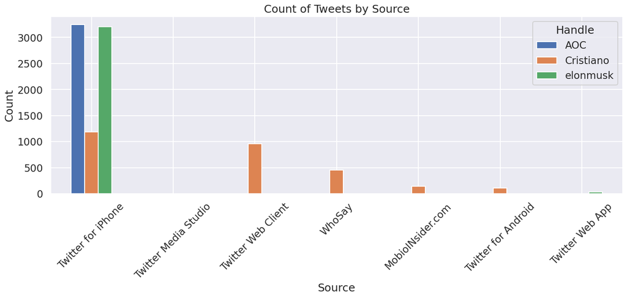

```python
make_bar_plot(device_counts.T, title="Count of Tweets by Source",
               xlabel="Source", ylabel="Count")
plt.xticks(rotation=45)
plt.legend(title="Handle");
```

### So...

We just looked at the top 5 most commonly used devices for each user. However, we used the number of tweets as a measure, but proportions of tweets may be a better meassure than the number of tweets because each user is a different sample, and their sizes vary so it is not expected for them to use different platforms in teh same rate. When it might be better to compare these distributions by comparing *proportions* of tweets?

## When?

Once that I explored the sources of each of the tweets, I performed some time series analysis. A look into the temporal aspect of the data could reveal insights about how a user spends their day, when they eat and sleep, etc. In this section, I focused on the time at which each tweet was posted.

### By Hour

The following function `add_hour` takes in a tweets dataframe `df`, and two column names `time_col` and `result_col`. The function uses the timestamps in the `time_col` column to store in a new column `result_col` the computed hour of the day as a floating point number according to the formula:

$$ \text{hour} + \frac{\text{minute}}{60} + \frac{\text{second}}{60^{2}} $$

The below code calls the `add_hour` function and updates each tweets dataframe by using the `created_at` timestamp column to calculate and store the `hour` column.

```python
def add_hour(df, time_col, result_col):
    df[result_col] = df[time_col].dt.hour + df[time_col].dt.minute / 60 + df[time_col].dt.second / 60 ** 2
    return df

tweets = {handle: add_hour(df, "created_at", "hour") for handle, df in tweets.items()}
tweets["AOC"]["hour"].head()
```

```
id
1358149122264563712    20.377222
1358147616400408576    20.277500
1358145332316667909    20.126389
1358145218407759875    20.118611
1358144207333036040    20.051667
Name: hour, dtype: float64
```

With the new `hour` column, I could take a look at the distribution of tweets for each user by time of day. The following cell helps create a density plot on the number of tweets based on the hour they are posted.

The function `bin_df` takes in a dataframe, an array of bins, and a column name; it bins the the values in the specified column, returning a dataframe with the bin lower bound and the number of elements in the bin. This function uses [`pd.cut`](https://pandas.pydata.org/pandas-docs/stable/reference/api/pandas.cut.html), a pandas [utility](https://pandas.pydata.org/pandas-docs/stable/reference/api/pandas.cut.html) for binning numerical values that I found helpful.

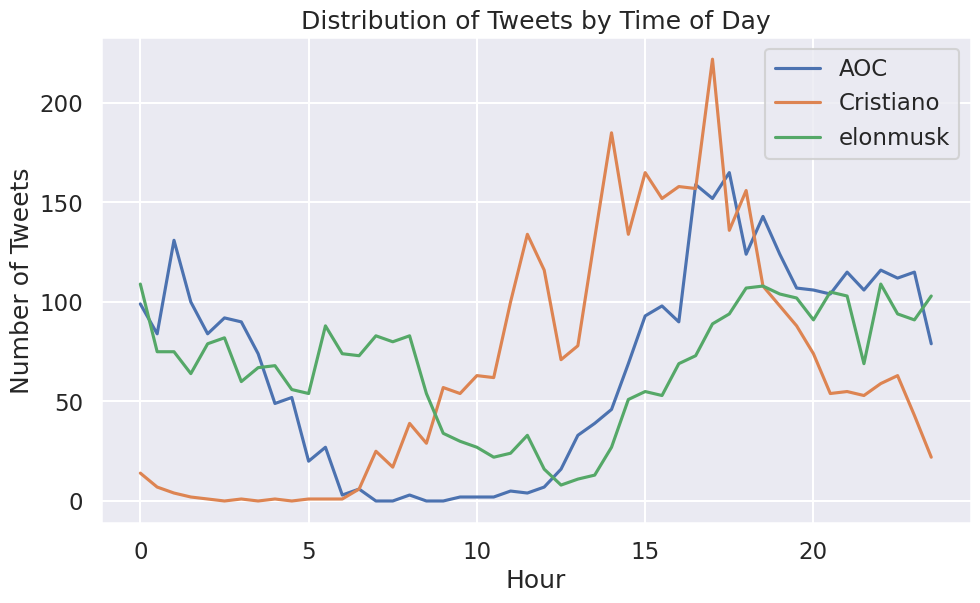

```python
def bin_df(df, bins, colname):
    binned = pd.cut(df[colname], bins).value_counts().sort_index()
    return pd.DataFrame({"counts": binned, "bin": bins[:-1]})

hour_bins = np.arange(0, 24.5, .5)
binned_hours = {handle: bin_df(df, hour_bins, "hour") for handle, df in tweets.items()}

make_line_plot(binned_hours, "bin", "counts", title="Distribution of Tweets by Time of Day",
               xlabel="Hour", ylabel="Number of Tweets")
```

### An Observation

Comparing Cristiano's distribution with those of AOC and Elon Musk. In particular, the distributions before and after Hour 6, it is clear that they live in different Time Zones.

To account for different locations of each user in my analysis, I adjusted the `created_at` timestamp for each tweet to the respective timezone of each user. The following function `convert_timezone` takes in a tweets dataframe `df` and a timezone `new_tz` and adds a new column `converted_time` that has the adjusted `created_at` timestamp for each tweet. The timezone for each user is provided in `timezones`.

```python
tweets["AOC"].head(1)
```

| id | created_at | id_str | full_text | truncated | display_text_range | entities | source | in_reply_to_status_id | in_reply_to_status_id_str | in_reply_to_user_id | ... | retweeted | lang | possibly_sensitive | extended_entities | quoted_status_id | quoted_status_id_str | quoted_status_permalink | quoted_status | device | hour |
| --- | --- | --- | --- | --- | --- | --- | --- | --- | --- | --- | --- | --- | --- | --- | --- | --- | --- | --- | --- | --- | --- |
| 1358149122264563712 | 2021-02-06 20:22:38+00:00 | 1358149122264563712 | RT @RepEscobar: Our country has the moral obligation and responsibility to reunite every single family separated at the southern border.\n\nT… | False | [0, 140] | {'hashtags': [], 'symbols': [], 'user_mentions': [{'screen_name': 'RepEscobar', 'name': 'Rep. Veronica Escobar', 'id': 1075517806551154689, 'id_str': '1075517806551154689', 'indices': [3, 14]}], 'urls… | <a href="http://twitter.com/download/iphone" rel="nofollow">Twitter for iPhone</a> | NaN | NaN | NaN | ... | False | en | NaN | NaN | NaN | NaN | NaN | NaN | Twitter for iPhone | 20.377222 |

1 rows × 32 columns

```python
def convert_timezone(df, new_tz):
    df["converted_time"] = df["created_at"].dt.tz_convert(new_tz)
    return df

timezones = {"AOC": "EST", "Cristiano": "Europe/Lisbon", "elonmusk": "America/Los_Angeles"}

tweets = {handle: convert_timezone(df, tz) for (handle, df), tz in zip(tweets.items(), timezones.values())}
```

With the adjusted timestamps for each user based on their timezone, here's a look again at the distribution of tweets by time of day.

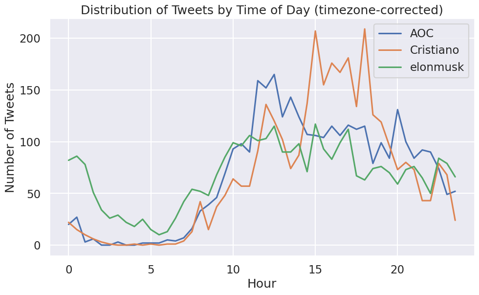

```python
tweets = {handle: add_hour(df, "converted_time", "converted_hour") for handle, df in tweets.items()}
binned_hours = {handle: bin_df(df, hour_bins, "converted_hour") for handle, df in tweets.items()}

make_line_plot(binned_hours, "bin", "counts", title="Distribution of Tweets by Time of Day (timezone-corrected)",
               xlabel="Hour", ylabel="Number of Tweets")
```

## Sentiment

In the past few sections, I explored the sources of the tweets and when they are posted. Although on their own, they might not seem particularly intricate, combined with the power of regular expressions, they could actually help us infer a lot about the users. In this section, I continued building on the past analysis and specifically looking at the sentiment of each tweet -- this would lead to a much more direct and detailed understanding of how the users view certain subjects and people.

But wait, how can we actually measure the sentiment of each tweet? In this case, I could use the words in the text of a tweet for our calculation! For example, the word "love" within the sentence "I love America!" has a positive sentiment, whereas the word "hate" within the sentence "I hate taxes!" has a negative sentiment. In addition, some words have stronger positive / negative sentiment than others: "I love America." is more positive than "I like America."  
I made use of the [VADER (Valence Aware Dictionary and sEntiment Reasoner)](https://github.com/cjhutto/vaderSentiment) lexicon to analyze the sentiment of AOC's tweets. VADER is a lexicon and rule-based sentiment analysis tool that is specifically attuned to sentiments expressed in social media which is great for this usage.

The VADER lexicon gives the sentiment of individual words. The following cell to show the first few rows of the lexicon:

```python
print(''.join(open("vader_lexicon.txt").readlines()[:10]))
```

```
$:	-1.5	0.80623	[-1, -1, -1, -1, -3, -1, -3, -1, -2, -1]
%)	-0.4	1.0198	[-1, 0, -1, 0, 0, -2, -1, 2, -1, 0]
%-)	-1.5	1.43178	[-2, 0, -2, -2, -1, 2, -2, -3, -2, -3]
&-:	-0.4	1.42829	[-3, -1, 0, 0, -1, -1, -1, 2, -1, 2]
&:	-0.7	0.64031	[0, -1, -1, -1, 1, -1, -1, -1, -1, -1]
( '}{' )	1.6	0.66332	[1, 2, 2, 1, 1, 2, 2, 1, 3, 1]
(%	-0.9	0.9434	[0, 0, 1, -1, -1, -1, -2, -2, -1, -2]
('-:	2.2	1.16619	[4, 1, 4, 3, 1, 2, 3, 1, 2, 1]
(':	2.3	0.9	[1, 3, 3, 2, 2, 4, 2, 3, 1, 2]
((-:	2.1	0.53852	[2, 2, 2, 1, 2, 3, 2, 2, 3, 2]
```

As you can see, the lexicon contains emojis too! Each row contains a word and the *polarity* of that word, measuring how positive or negative the word is.

### VADER Sentiment Analysis

[VADER](https://github.com/cjhutto/vaderSentiment#introduction) is a tool that can quantitatively describe the polarity or "sentiment" of a word.

VADER doesn't "read" sentences, but works by parsing sentences into words, assigning a preset generalized score from their testing sets to each word separately.

### Polarity

I first loaded in the data containing all the sentiments. I Read `vader_lexicon.txt` into a dataframe called `sent`. The index of the dataframe as the words in the lexicon and was named `token`. `sent` has one column named `polarity`, storing the polarity of each word.

```python
sent = pd.read_csv("vader_lexicon.txt", sep='\t', header=None).rename(
    columns={0: "token", 1: "polarity"}).set_index("token").drop(columns=[2,3])
sent.head()
```

| token | polarity |
| --- | --- |
| $: | -1.5 |
| %) | -0.4 |
| %-) | -1.5 |
| &-: | -0.4 |
| &: | -0.7 |

### More Patterns

Before further analysis, I needed some more tools that could help me extract the necessary information and clean the data.

The following regular expressions helped me match part of a tweet that I either (i) wanted to remove or (ii) was interested in learning more about.

#### Punctuation

Assigning a regular expression to a new variable `punct_re` that captures all of the punctuations within a tweet. I considered punctuation to be any non-word, non-whitespace character.

A word character is any character that is alphanumeric or an underscore. A whitespace character is any character that is a space, a tab, a new line, or a carriage return.

```python
punct_re = r'\W'

re.sub(punct_re, " ", tweets["AOC"].iloc[0]["full_text"])
```

```
'RT  RepEscobar  Our country has the moral obligation and responsibility to reunite every single family separated at the southern border   T '
```

#### Mentions

Assigning a regular expression to a new variable `mentions_re` that matches any mention in a tweet. The regular expression uses a capturing group to extract the user's username in a mention.

```python
mentions_re = r"@(\w+)"

re.findall(mentions_re, tweets["AOC"].iloc[0]["full_text"])
```

```
['RepEscobar']
```

### Tweet Sentiments and User Mentions

As seen in the previous part of this project, there are actually a lot of interesting components that I could extract out of a tweet for further analysis. For the rest however, I focused on one particular case: the sentiment of each tweet in relation to the users mentioned within it.

To calculate the sentiments for a sentence, I followed this procedure:

1. Removed the punctuation from each tweet so I could analyze the words.
2. For each tweet, found the sentiment of each word.
3. Calculated the sentiment of each tweet by taking the sum of the sentiments of its words.

### Cleanning

I used `punct_re` regular expression from the previous part to clean up the text a bit more. The goal here was to remove all of the punctuations to ensure words can be properly matched with those from VADER to actually calculate the full sentiment score.

The following function `sanitize_texts` takes in a table `df` and adds a new column `clean_text` by converting all characters in its original `full_text` column to lower case and replace all instances of punctuations with a space character.

```python
def sanitize_texts(df):
    df["clean_text"] = df["full_text"].str.replace(punct_re, " ").str.lower()
    return df

tweets = {handle: sanitize_texts(df) for handle, df in tweets.items()}
tweets["AOC"]["clean_text"].head()
```

```
id
1358149122264563712                                                                                     rt  repescobar  our country has the moral obligation and responsibility to reunite every single family separated at the southern border   t
1358147616400408576                                                                                     rt  rokhanna  what happens when we guarantee  15 hour     31  of black workers and 26  of latinx workers get raises    a majority of essent
1358145332316667909                                                                                                                                                                                                 source  https   t co 3o5jer6zpd
1358145218407759875                                             joe cunningham pledged to never take corporate pac money  and he never did  mace said she ll cash every check she gets  yet another way this is a downgrade  https   t co dytsqxkxgu
1358144207333036040    what s even more gross is that mace takes corporate pac money   she s already funded by corporations  now she s choosing to swindle working people on top of it   peak scam artistry  caps for cash   https   t co ccvxgdf6id
Name: clean_text, dtype: object
```

### Extraction

With the texts sanitized, I could now extract all the user mentions from tweets.

The following function `extract_mentions` takes in the **`full_text`** (not `clean_text`!) column from a tweets dataframe and uses `mentions_re` to extract all the mentions in a dataframe. The returned dataframe is:

- single-indexed by the IDs of the tweets
- has one row for each mention
- has one column named `mentions`, which contains each mention in all lower-cased characters

```python
def extract_mentions(full_texts):
    full_texts = full_texts.str.lower()
    mentions = full_texts.str.extractall(mentions_re).reset_index().rename(columns={0: "mentions"})
    return mentions[["mentions"]]

display(extract_mentions(tweets["AOC"]["full_text"]).head())

mentions = {handle: extract_mentions(df["full_text"]) for handle, df in tweets.items()}
horiz_concat_df(mentions).head()
```

|  | mentions |
| --- | --- |
| 0 | repescobar |
| 1 | rokhanna |
| 2 | jaketapper |
| 3 | repnancymace |
| 4 | aoc |

|  | AOC mentions | Cristiano mentions | elonmusk mentions |
| --- | --- | --- | --- |
| 0 | repescobar | sixpadhomegym | dumdin7 |
| 1 | rokhanna | globe_soccer | grimezsz |
| 2 | jaketapper | pestanacr7 | grimezsz |
| 3 | repnancymace | goldenfootofficial | kristennetten |
| 4 | aoc | herbalife | kristennetten |

```python
horiz_mentions = horiz_concat_df(mentions)
horiz_mentions.loc[0]["AOC"]["mentions"]
```

```
'repescobar'
```

### Tidying Up the Data

I then converted the tweets into what's called a [*tidy format*](https://cran.r-project.org/web/packages/tidyr/vignettes/tidy-data.html) to make the sentiments easier to calculate. The `to_tidy_format` function implemented for you uses the `clean_text` column of each tweets dataframe to create a tidy table, which is:

- single-indexed by the IDs of the tweets, for every word in the tweet.
- has one column named `word`, which contains the individual words of each tweet.

The following function converts the table into the tidy format. Taking a look at the first 5 rows from the "tidied" tweets dataframe for AOC we can see that the structure has changed.

```python
def to_tidy_format(df):
    tidy = (
        df["clean_text"]
        .str.split()
        .explode()
        .to_frame()
        .rename(columns={"clean_text": "word"})
    )
    return tidy

tidy_tweets = {handle: to_tidy_format(df) for handle, df in tweets.items()}
tidy_tweets["AOC"].head()
```

| id | word |
| --- | --- |
| 1358149122264563712 | rt |
| 1358149122264563712 | repescobar |
| 1358149122264563712 | our |
| 1358149122264563712 | country |
| 1358149122264563712 | has |

### Adding in the Polarity Score

Once I had the table in the tidy format, it became much easier to find the sentiment of each tweet: I could just join the table with the lexicon table.

The following `add_polarity` function added a new `polarity` column to the `df` table. The `polarity` column contained the sum of the sentiment polarity of each word in the text of the tweet.

```python
# just run this cell
def add_polarity(df, tidy_df):
    df["polarity"] = (
        tidy_df
        .merge(sent, how='left', left_on='word', right_index=True)
        .reset_index()
        .loc[:, ['id', 'polarity']]
        .fillna(0)
        .groupby('id')
        .sum()
    )
    return df

tweets = {handle: add_polarity(df, tidy_df) for (handle, df), tidy_df in \
          zip(tweets.items(), tidy_tweets.values())}
tweets["AOC"][["clean_text", "polarity"]].head()
```

| id | clean_text | polarity |
| --- | --- | --- |
| 1358149122264563712 | rt repescobar our country has the moral obligation and responsibility to reunite every single family separated at the southern border t | 0.0 |
| 1358147616400408576 | rt rokhanna what happens when we guarantee 15 hour 31 of black workers and 26 of latinx workers get raises a majority of essent | 1.0 |
| 1358145332316667909 | source https t co 3o5jer6zpd | 0.0 |
| 1358145218407759875 | joe cunningham pledged to never take corporate pac money and he never did mace said she ll cash every check she gets yet another way this is a downgrade https t co dytsqxkxgu | 0.0 |
| 1358144207333036040 | what s even more gross is that mace takes corporate pac money she s already funded by corporations now she s choosing to swindle working people on top of it peak scam artistry caps for cash https t co… | -6.4 |

Finally, with my polarity column in place, I could finally explore how the sentiment of each tweet related to the user(s) mentioned in it.

The function `mention_polarity` takes in a mentions dataframe `mentions` and the original tweets dataframe `df` and returns a series where the mentioned users are the index and the corresponding mean sentiment scores of the tweets mentioning them are the values.

```python
def mention_polarity(df, mention_df):
    return mention_df.merge(df.reset_index(), left_index=True, right_index=True).groupby("mentions")["polarity"].mean()

aoc_mention_polarity = mention_polarity(tweets["AOC"],mentions["AOC"]).sort_values(ascending=False)
aoc_mention_polarity
```

```
mentions
ncoltrain          16.3
morningedition     15.4
wnyc               13.1
sandysal14         12.6
biaggi4ny          11.3
                   ...
marshablackburn   -11.1
faircount         -12.6
fatjoe            -14.0
budgethawks       -15.2
facebooklive      -15.7
Name: polarity, Length: 1182, dtype: float64
```

## Exploratory Data Analysis

There is still far more to explore within the data and build upon what I had uncovered. So I came up with a new perspective that could expand upon my analysis of the sentiment of each tweet.

For this part, I performed some text analysis on my `tweets` dataset. The analysis consists of two parts:

1. a piece of code that manipulates `tweets` in and produces informative output.
2. a short description of the findings of the analysis.

```python
help(make_line_plot)
```

```
Help on function make_line_plot in module ds100_utils:

make_line_plot(df_dict, x_col, y_col, include=None, title=None, xlabel=None, ylabel=None, legend=True)
    Plot a line plot of two columns for each dataframe in `df_dict`.

    Uses `sns.lineplot` to plot a line plot of two columns for each
    dataframe in `df_dict`. The keys of `df_dict` are used as entries in
    the legend when `legend` is `True`.

    Parameters
    ----------
        df_dict: dict[str: pd.DataFrame]
            a dictionary mapping handles to dataframes with the data to plot
        x_col: str
            the name of a column in each dataframe in `df_dict` to plot on
            the x-axis
        y_col: str
            the name of a column in each dataframe in `df_dict` to plot on
            the y-axis
        include: list[str], optional
            a list of handles to include in the plot; all keys in `df_dict` not
            present in `include`, if specified, will *not* be included in the plot
        title: str, optional
            a title for the plot
        xlabel: str, optional
            a label for the x-axis; if unspecified, `x_col` is used
        ylabel: str, optional
            a label for the y-axis; if unspecified, `y_col` is used
        legend: bool, optional
            whether to include a legend with each key in `df_dict`
```

```python
def polarity_by_device(original_df):
    df = pd.DataFrame()
    for key in original_df.keys():
        df[key] = original_df[key].groupby("source")["polarity"].mean()
    return df.fillna(0).reset_index()

polarity_by_device(tweets).fillna(0).reset_index()
```

|  | index | source | AOC | Cristiano | elonmusk |
| --- | --- | --- | --- | --- | --- |
| 0 | 0 | <a href="http://twitter.com/download/iphone" rel="nofollow">Twitter for iPhone</a> | 0.570293 | 1.686137 | 1.011462 |
| 1 | 1 | <a href="https://studio.twitter.com" rel="nofollow">Twitter Media Studio</a> | 2.550000 | 2.189873 | 0.000000 |

```python
def rename_device(df):
    df["device"] = df["source"].str.extract(q2b_pattern, expand=False)
    return df.drop(columns="source").set_index("device")

rename_device(polarity_by_device(tweets))
```

| device | AOC | Cristiano | elonmusk |
| --- | --- | --- | --- |
| Twitter for iPhone | 0.570293 | 1.686137 | 1.011462 |
| Twitter Media Studio | 2.550000 | 2.189873 | 0.000000 |

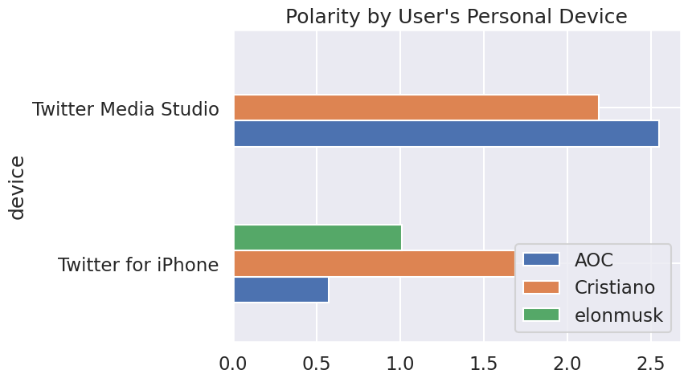

```python
rename_device(polarity_by_device(tweets)).plot.barh(title="Polarity by User's Personal Device")
```

```python
def polarity_by_user(original_df):
    df = pd.DataFrame()
    for key in original_df.keys():
        df[key]= original_df[key]["polarity"].reset_index().drop("id", axis = 1)
    return df.mean()

polarity_by_user(tweets)
```

```
AOC          0.571512
Cristiano    2.287086
elonmusk     1.005218
dtype: float64
```

### Conclusion

For my EDA, I decided to filter the polarity of each user's tweet by the official Twitter platform's. In this way, I get a glimpse of the average polarity of each user as they are the ones who personally share something on social media.

It is interesting to observe how the means of each user differ.

*This could tell us more about the type of discourse that they present.*